# 2D Stabelement (Truss) – Beschreibung und Implementierung

Dieser Abschnitt dokumentiert die Funktionsweise des in `Programmieraufgabe/solver.py` implementierten 2D-Stabelements (Truss). Es erläutert Knoten/DOFs, benötigte Eingaben, mögliche Lasten, die lokale Elementsteifigkeit, die Transformation ins globale Koordinatensystem, die Assemblierung, das Lösen des linearen Gleichungssystems und die Nachverarbeitung (Stabkräfte, Dehnungen, Spannungen, Auflagerkräfte).

Im Folgenden werden Formeln in LaTeX angegeben und durch Codeauszüge aus `solver.py` belegt.

## Elementbeschreibung

- **Knotenanzahl**: 2 Knoten pro Stabelement.
- **Freiheitsgrade je Knoten**: Verschiebungen in x- und y-Richtung, also `u_x`, `u_y`. Insgesamt 4 DOFs pro Element.
- **Benötigte Eingaben pro Element**: Knoten-IDs `n1`, `n2`, Youngscher Modul `E`, Querschnittsfläche `A`. Standardwerte können über `model['defaults']` vorgegeben sein.
- **Belastungen**: In diesem Solver werden Knotenlasten `fx`, `fy` unterstützt.
- **Übertragene Kräfte**: Das Stabelement trägt ausschließlich **axiale** Kräfte (Zug/Druck), keine Biegung/Schub.

Die globale Gleichgewichtsbedingung lautet: $$\,\mathbf{K} \mathbf{u} = \mathbf{f}\,,$$ wobei `K` die globale Steifigkeitsmatrix, `U` der Verschiebungsvektor und `f` der Lastvektor ist. Da allerdings `f` beim Programmieren oft als Platzhalter für Funktion verwendet wird, wird hier im Code die Variable `R` genutzt.

Zuordnung der DOFs (Auszug aus `solver.py` Zeile 36):

```
def dof_index(nid: int) -> Tuple[int, int]:
    i = id_to_idx[nid]
    return 2 * i, 2 * i + 1
```

Die Zuordung erfolgt wie folgt:

- Knoten-ID = 0 -> DOF u_x = 0, DOF u_y = 1
- Knoten-ID = 1 -> DOF u_x = 2, DOF u_y = 3
- Knoten-ID = 2 -> DOF u_x = 4, DOF u_y = 5
- u.s.w.

## Geometrie und Richtungskosinus

Für ein Element zwischen den Knoten $(x_1,y_1)$ und $(x_2,y_2)$ gilt die Stablänge $$L=\sqrt{(x_2-x_1)^2+(y_2-y_1)^2}.$$ Die Richtungskosinus sind $$c=\frac{x_2-x_1}{L},\quad s=\frac{y_2-y_1}{L}.$$

Auszug aus `model.json`:

```
"nodes": [
    {
      "id": 1,
      "x": -3.0,
      "y": 0.0
    }, .... ]
```

Auszug aus `solver.py` Zeile 41:

```
x1, y1 = n1["x"], n1["y"]
x2, y2 = n2["x"], n2["y"]
dx, dy = x2 - x1, y2 - y1
L = math.hypot(dx, dy) # Euklidische Norm
c, s = dx / L, dy / L
```

## Lokale Steifigkeit und Transformation

In lokalen Koordinaten (Längsrichtung des Stabes) lautet die Elementsteifigkeitsmatrix (VL1 S.22) $$\mathbf{k}^{(e)}_{\ell} = \frac{EA}{L} \begin{bmatrix} 1 & -1 \\ -1 & 1 \end{bmatrix}. $$

Die globale Elementsteifigkeit ergibt sich durch (VL2 S.5) $$\mathbf{k}^{(e)}_{g} = \mathbf{T}^\top\, \mathbf{k}^{(e)}_{\ell} \ \mathbf{T} = \frac{EA}{L} \begin{bmatrix} c^2 & cs & -c^2 & -cs \\ cs & s^2 & -cs & -s^2 \\ -c^2 & -cs & c^2 & cs \\ -cs & -s^2 & cs & s^2 \end{bmatrix}. $$

## Globale Elementsteifigkeit im Code

`solver.py` bildet direkt die globale 4x4-Elementmatrix gemäß obiger Formel:

```
EA_L = e.get("E", model.get("defaults", {}).get("E", 210e9)) * e.get("A", model.get("defaults", {}).get("A", 1e-4)) / L
ke = EA_L * np.array(
    [
        [ c*c,  c*s, -c*c, -c*s],
        [ c*s,  s*s, -c*s, -s*s],
        [-c*c, -c*s,  c*c,  c*s],
        [-c*s, -s*s,  c*s,  s*s],
    ],
    dtype=float,
)
```

Hier entspricht `EA_L = (E,A)/L` dem Vorfaktor.

```
e.get("E", model.get("defaults", {}).get("E", 210e9))
```

funktioniert dabei wie folgt:

```
value = dict.get(key, alternative)
```

Das Dict `e` für ein Element wird befragt, ob ein `value` für den `key` vorliegt, falls nicht wird auf die `alternativ` zurück. Der `alternativ`-Wert ist wiederum der `default` vom Model.

So gelingt es, jedem Element eigene E-Module und Querschnittsflächen zuzuordnen.

## Aufbau eines Elementes in der model.json

Um den nächsten Schritt verstehen zu können ist es entscheidend zu verstehen, wie ein Element gespeichert ist. Es handelt sich dabei um ein flaches Dictonary.

```
"elements": [
    {
      "id": 1,
      "n1": 1,
      "n2": 2,
      "E": 210000000000.0,
      "A": 0.0001
    }, ..... ]
```

## Assemblierung des Gesamtsystems

Die Elementmatrix wird über die Element-DOF-Indizes in die globale Matrix addiert. Lasten werden als Knotenkräfte zusammengesetzt, und Lager werden als festgesetzte DOFs erfasst.

Element-Einbau in `K`:

```
dofs = (*dof_index(n1["id"]), *dof_index(n2["id"]))
for i in range(4):
    for j in range(4):
        K[dofs[i], dofs[j]] += ke[i, j]
```

Die Schleife iteriert durch alle Einträge der globalen Elementsteifigkeitsmatrix und addiert sie zum Gesamtsystem an den entsprechenden Stellen (VL S.28).

Knotenlasten `R` (Ich habe mich dazu entschieden den Lastvektor `f` als `R` zu bezeichnen.):

Auszug aus `solver.py` Zeile 65:

```
for ld in loads_list:
    ux_i, uy_i = dof_index(ld["node"])  # ux_i is x dof index, not ux value
    R[ux_i] += ld.get("fx", 0.0)
    R[uy_i] += ld.get("fy", 0.0)
```

Die Schleife geht durch die Außenlasten und trägt diese im Lastvektor ein.

Auszug aus model.json:

```
 "loads": [
    {
      "node": 1,
      "fx": 0.0,
      "fy": -5000.0
    }, ... ]
```

Lagerbedingungen (fixierte DOFs):

```
fixed_dofs = []
for spt in supports_list:
    nid = spt["node"]
    ux_flag = bool(spt.get("ux", False))
    uy_flag = bool(spt.get("uy", False))
    dof_x, dof_y = dof_index(nid)
    if ux_flag:
        fixed_dofs.append(dof_x)
    if uy_flag:
        fixed_dofs.append(dof_y)
```

Auszug aus `model.json`:

```
"supports": [
    {
      "node": 17,
      "ux": true,
      "uy": true
    }, ..... ]
```

## Lösen des Gleichungssystems

Auszug aus `solver.py` Zeile 97:

```
Kff = K[np.ix_(free, free)]
Rf = R[free]
Uf = np.linalg.solve(Kff, Rf)
U[free] = Uf
```

`Kff` beinhaltet nur die "freien" Spalten und Zeile der Steifigkeitsmatrix. Dies entspricht dem Streichen der Spalten und Zeilen, wie in VL3 S.4

`np.ix_()` ist ein kleines Indexing-Gadget, das aus 1D-Indexlisten “passende” Index-Arrays für ein Kreuzprodukt baut, damit du sauber eine Submatrix aus einer 2D-Matrix ziehen kannst. `Kff = K[np.ix_(free, free)]` bedeutet: nimm alle Zeilen aus K, deren Indizes in free liegen, und alle Spalten aus K, deren Indizes in free liegen → also die free–free-Blockmatrix.

Auszug aus `solver.py` Zeile 81:

```
all_dofs = np.arange(n_dof)
fixed_dofs = np.array(sorted(set(fixed_dofs)), dtype=int)
free_dofs = np.array([d for d in all_dofs if d not in set(fixed_dofs)], dtype=int)
```

Ein Solver wird von numpy bereitgestellt und genutzt. Ich habe auch noch einen eigenen Solver aus dem Numerik Kurs, habe mich aber dagegen entschieden, weil es den Rahmen sprengen würde und weil es bei der Programmierung in Matlab auch erlaubt ist. Der Solver löst nun das System: `Uf = np.linalg.solve(Kff, Rf)`

Mit `U[free] = Uf` werden dann die Verschiebungen in Eingetragen. Fixierte Freiheitsgrade bleiben bei Null. Fertig. Weiter zur Auswertung.

## Auflagerkräfte (Reaktionen)

Die Auflagerreaktionen ergeben sich aus (vergleichbar mit VL1 S.33) $$\mathbf{R}_{reac} = \mathbf{K}\,\mathbf{U} - \mathbf{R}.$$

Auszug `solver.py`Zeile 98:

```
reac_full = K @ U - R
reactions = []
for d in fixed:
    node_index = d // 2
    nid = next(k for k, v in id_to_idx.items() if v == node_index)
    if d % 2 == 0:
        reactions.append({"node": nid, "rx": float(reac_full[d]), "ry": 0.0})
    else:
        reactions.append({"node": nid, "rx": 0.0, "ry": float(reac_full[d])})
```

Der Code `nid = next(k for k, v in id_to_idx.items() if v == node_index)` heißt: „Gib mir den ersten Key k, dessen Value v gleich node_index ist.“

`id_to_idx` ist dabei ein Dictonary, welches den node_id`s, welche dem Node-Index eines Lager entsprechen, eine fortlaufende Nummer zuordnet.

`if d % 2 == 0:` stellt, fest ob es eine grader Index ist, dies entspricht einer Lagerreaktiuon in x-Richtung.

Nun werden die Reaktionskräfte wieder den Knoten zugewiesen und summiert.

Auszug `solver.py`Zeile 108:

```
reac_by_node: Dict[int, Tuple[float, float]] = {}
for r in reactions:
    nid = r["node"]
    rx, ry = reac_by_node.get(nid, (0.0, 0.0))
    rx += r.get("rx", 0.0)
    ry += r.get("ry", 0.0)
    reac_by_node[nid] = (rx, ry)
reactions_combined = [{"node": nid, "rx": float(rx), "ry": float(ry)} for nid, (rx, ry) in reac_by_node.items()]

sum_rx = float(sum(r["rx"] for r in reactions_combined))
sum_ry = float(sum(r["ry"] for r in reactions_combined))
sum_R = float(math.hypot(sum_rx, sum_ry))
```

Nun werden die Verschiebungen den Knoten zugewiesen.

Auszug `solver.py` Zeile 122:

```
node_ids = sorted(id_to_idx.keys(), key=lambda k: id_to_idx[k])
node_results = []
for nid in node_ids:
    i = id_to_idx[nid]
    node_results.append({"id": nid, "ux": float(U[2 * i]), "uy": float(U[2 * i + 1])})
```

## Nachverarbeitung: Stabkraft, Dehnung, Spannung

Die axiale Verlängerung des Elements ist $$\delta = [-c,\,-s,\,c,\,s]\,\mathbf{u}_e,$$ wobei $\mathbf{u}_e=[u_{1x},u_{1y},u_{2x},u_{2y}]^\top$. Daraus folgen $$N = \frac{EA}{L}\,\delta, \qquad \varepsilon = \frac{\delta}{L}, \qquad \sigma = E\,\varepsilon.$$

Auszug aus `solver.py` Zeile 145:

```
c, s = dx / L, dy / L
ue = np.array([U[2 * i1], U[2 * i1 + 1], U[2 * i2], U[2 * i2 + 1]])
delta = np.array([-c, -s, c, s]) @ ue
E = e.get("E", model.get("defaults", {}).get("E", 210e9))
A = e.get("A", model.get("defaults", {}).get("A", 1e-4))
N = (E * A / L) * delta
strain = delta / L
stress = E * strain
```

Hier wird eine Schleife genutzt um durch die Elemente zu Iterieren, so wie bereits im Beginn der Assemblierung.

Die Zeile `ue = np.array([U[2 * i1], U[2 * i1 + 1], U[2 * i2], U[2 * i2 + 1]])` holt sich die Einträge aus dem Globalen Verschiebungsvektor, die zu dem passenden Element gehören.

Nun erfolgt nur noch die Eintragung der Ergebnisse in ein Dict und das speichern der Ergebnisse.

Auszug aus `solver.py` Zeile 160:

```
results = {
    "nodes": node_results,
    "elements": elem_results,
    "reactions": reactions_combined,
    "reactions_sum": {"rx": sum_rx, "ry": sum_ry, "R": sum_R},
    "metadata": {
        "dof": int(n_dof),
        "free_dofs": int(getattr(free, 'size', len(free))),
        "fixed_dofs": int(getattr(fixed, 'size', len(fixed)))
    },
}
```

### Nachwort:

Auf den Aufbau der UI werde ich nicht weiter eingehen, da es nicht Teil der Aufgabenstellung ist. Ich war in der Lage es so schnell zu Programmieren, da ich beruflich mit Python arbeite (vorallem das erstellen von UI`s) und da ich bereits am Anfang des Semesters einige der Vorlesungsfolien vollständig in Python umgesetzt habe. Des weiteren habe ich bereits im letzten Semester den Kurs Numerik erfolgreich abgeschlossen, bei dem eine Menge in Python programmiert wird.

# Die drei Beispiele:

## Ein simples Brückenfachwerk

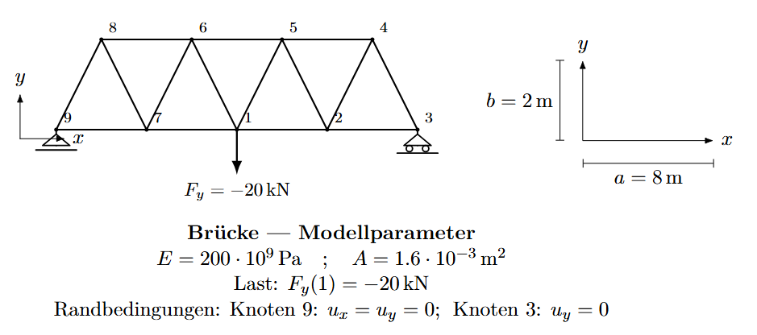

### Umsetzung im eigenem Preprozessor

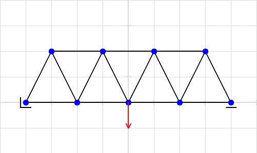

### Ergebins im eigenem Postprozessor

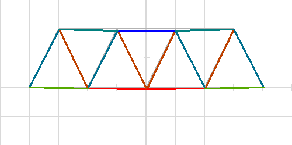

### Tabellen aus dem eigenem Solver

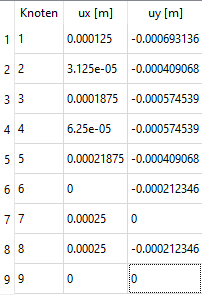

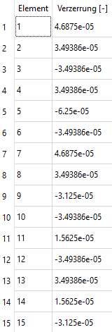

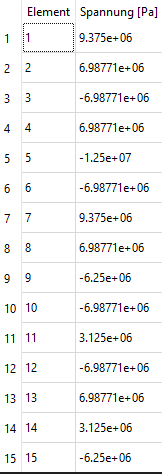

### Ergebnis aus Abaqus

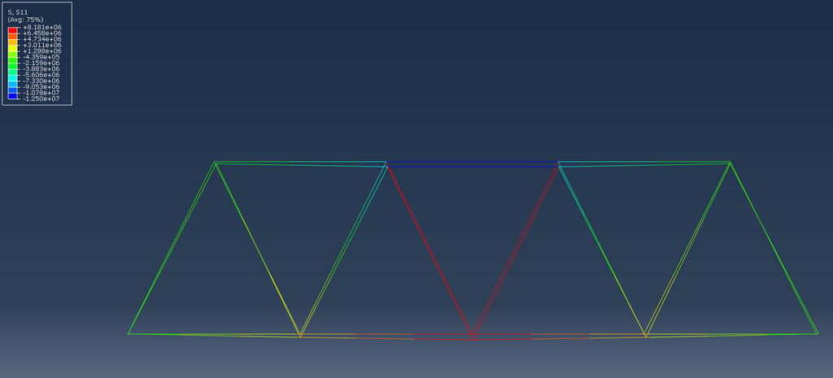

### Report aus Abaqus

```python
********************************************************************************
Field Output Report, written Wed Jan 28 22:10:55 2026

Source 1
---------

   ODB: C:/Temp/Job-1.odb
   Step: Step-1
   Frame: Increment      1: Step Time =    1.000

Loc 1 : Nodal values from source 1

Output sorted by column "Node Label".

Field Output reported at nodes for part: PART-1-1
   Computation algorithm: EXTRAPOLATE_COMPUTE_AVERAGE
   Averaged at nodes
   Averaging regions: ODB_REGIONS

            Node          RF.RF1          RF.RF2     U.Magnitude            U.U1            U.U2           E.E11           S.S11
           Label          @Loc 1          @Loc 1          @Loc 1          @Loc 1          @Loc 1          @Loc 1          @Loc 1
---------------------------------------------------------------------------------------------------------------------------------
               1              0.              0.     577.929E-06     62.5000E-06    -574.539E-06    -23.4375E-06     -4.6875E+06
               2              0.              0.     212.346E-06     149.078E-21    -212.346E-06    -10.4167E-06    -2.08333E+06
               3              0.              0.     463.884E-06     218.750E-06    -409.068E-06     15.6250E-06       3.125E+06
               4              0.         10.E+03     250.000E-06     250.000E-06    -10.0000E-33    -9.65678E-06    -1.93136E+06
               5              0.              0.     604.360E-06     187.500E-06    -574.539E-06    -23.4375E-06     -4.6875E+06
               6              0.              0.     328.011E-06     250.000E-06    -212.346E-06    -10.4167E-06    -2.08333E+06
               7    -15.4614E-12         10.E+03              0.              0.    -10.0000E-33    -9.65678E-06    -1.93136E+06
               8              0.              0.     410.260E-06     31.2500E-06    -409.068E-06     15.6250E-06       3.125E+06
               9              0.              0.     704.317E-06     125.000E-06    -693.136E-06     40.9068E-06     8.18136E+06


  Minimum           -15.4614E-12              0.              0.              0.    -693.136E-06    -23.4375E-06     -4.6875E+06
         At Node               7               9               7               7               9               5               5

  Maximum                     0.         10.E+03     704.317E-06        250.E-06        -10.E-33     40.9068E-06     8.18136E+06
         At Node               9               7               9               6               7               9               9

           Total    -15.4614E-12         20.E+03     3.55111E-03     1.12500E-03    -3.08504E-03    -14.8651E-06    -2.97302E+06


********************************************************************************
Field Output Report, written Wed Jan 28 22:11:51 2026

Source 1
---------

   ODB: C:/Temp/Job-1.odb
   Step: Step-1
   Frame: Increment      1: Step Time =    1.000

Loc 1 : Integration point values from source 1

Output sorted by column "Element Label".

Field Output reported at integration points for part: PART-1-1

         Element             Int           E.E11           S.S11
           Label              Pt          @Loc 1          @Loc 1
-----------------------------------------------------------------
               1               1    -31.2500E-06       -6.25E+06
               2               1     34.9386E-06     6.98771E+06
               3               1     15.6250E-06       3.125E+06
               4               1    -34.9386E-06    -6.98771E+06
               5               1    -62.5000E-06       -12.5E+06
               6               1    -31.2500E-06       -6.25E+06
               7               1    -34.9386E-06    -6.98771E+06
               8               1     15.6250E-06       3.125E+06
               9               1    -34.9386E-06    -6.98771E+06
              10               1     34.9386E-06     6.98771E+06
              11               1     46.8750E-06       9.375E+06
              12               1     34.9386E-06     6.98771E+06
              13               1    -34.9386E-06    -6.98771E+06
              14               1     34.9386E-06     6.98771E+06
              15               1     46.8750E-06       9.375E+06


  Minimum                              -62.5E-06       -12.5E+06
      At Element                               5               5
          Int Pt                               1               1

  Maximum                             46.875E-06       9.375E+06
      At Element                              15              15
          Int Pt                               1               1

           Total                    -3.63798E-12              0.
```

## Vergleich der Ergebnisse

### Knotenverschiebungen:

$\operatorname{rel} \Delta=\frac{\left|x_{\text {prog }}-x_{\text {abaqus }}\right|}{\max \left(\left|x_{\text {abaqus }}\right|, \text { tol }\right)} \cdot 100 \%$

[output not shown]

### Elementdehnung 𝜀 und Spannung 𝜎

| Elem (Abaqus) | Elem (Prog) | ε_prog [-] | ε_abaqus [-] | relΔε | σ_prog [Pa] | σ_abaqus [Pa] | relΔσ |
| --- | --- | --- | --- | --- | --- | --- | --- |
| 1 | 9 | -3.125e-05 | -3.125e-05 | 0% | -6.25e+06 | -6.25e+06 | 0% |
| 2 | 2 | 3.49386e-05 | 3.49386e-05 | 0% | 6.98771e+06 | 6.98771e+06 | 0% |
| 3 | 11 | 1.5625e-05 | 1.5625e-05 | 0% | 3.125e+06 | 3.125e+06 | 0% |
| 4 | 3 | -3.49386e-05 | -3.49386e-05 | 0% | -6.98771e+06 | -6.98771e+06 | 0% |
| 5 | 5 | -6.25e-05 | -6.25e-05 | 0% | -1.25e+07 | -1.25e+07 | 0% |
| 6 | 15 | -3.125e-05 | -3.125e-05 | 0% | -6.25e+06 | -6.25e+06 | 0% |
| 7 | 6 | -3.49386e-05 | -3.49386e-05 | 0% | -6.98771e+06 | -6.98771e+06 | 0% |
| 8 | 14 | 1.5625e-05 | 1.5625e-05 | 0% | 3.125e+06 | 3.125e+06 | 0% |
| 9 | 10 | -3.49386e-05 | -3.49386e-05 | 0% | -6.98771e+06 | -6.98771e+06 | 0% |
| 10 | 4 | 3.49386e-05 | 3.49386e-05 | 0% | 6.98771e+06 | 6.98771e+06 | 0% |
| 11 | 1 | 4.6875e-05 | 4.6875e-05 | 0% | 9.375e+06 | 9.375e+06 | 0% |
| 12 | 8 | 3.49386e-05 | 3.49386e-05 | 0% | 6.98771e+06 | 6.98771e+06 | 0% |
| 13 | 12 | -3.49386e-05 | -3.49386e-05 | 0% | -6.98771e+06 | -6.98771e+06 | 0% |
| 14 | 13 | 3.49386e-05 | 3.49386e-05 | 0% | 6.98771e+06 | 6.98771e+06 | 0% |
| 15 | 7 | 4.6875e-05 | 4.6875e-05 | 0% | 9.375e+06 | 9.375e+06 | 0% |

### Reaktionskräfte an Lagern $R_x, R_y$

| Node (Abaqus) | Node (Prog) | Rx_prog [N] | Rx_abaqus [N] | relΔRx | Ry_prog [N] | Ry_abaqus [N] | relΔRy |
| --- | --- | --- | --- | --- | --- | --- | --- |
| 4 | 7 | 0 | 0 | 0% | 10000 | 10000 | 0% |
| 7 | 9 | 0 | 0 | 0% | 10000 | 10000 | 0% |

## Das Katapult mit Gummizug

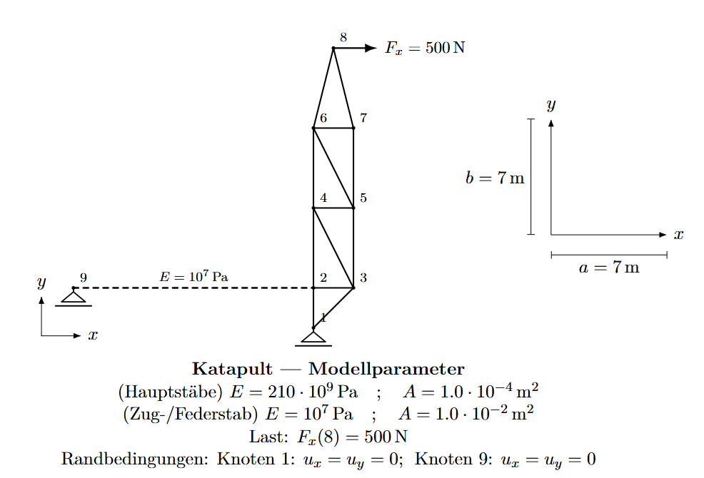

### Umsetzung im eigenem Preprozessor

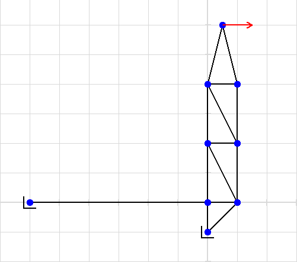

### Ergebnis im eigenem Postprozessor

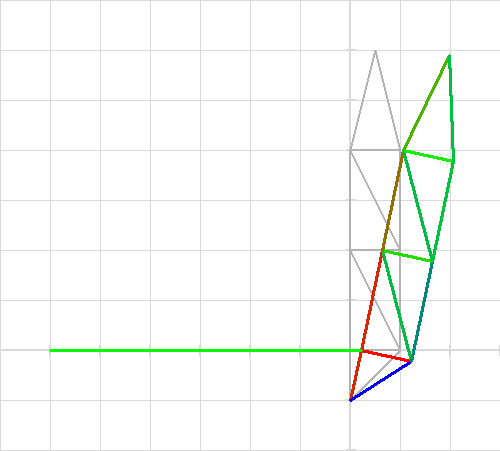

### Tabellen aus dem eigenem Solver

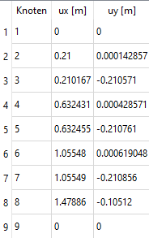

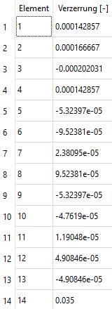

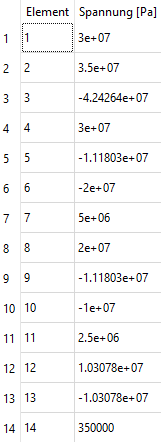

### Ergebnis aus Abaqus

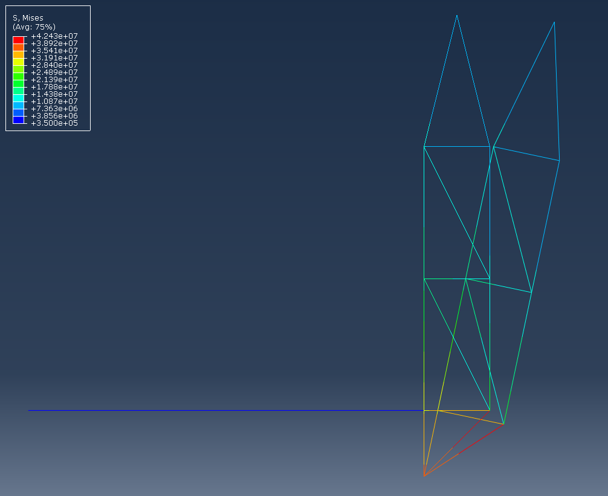